# InfantProdStudy

Catherine Laing

April 16, 2019

# Methods

Descriptively, 24/44 infants had at least one VMS consonant; 9 had two VMS in repertoire (5 females) two infants (one female) had three. The most common VMS consonant was /p,b/, which featured in 16 infants’ repertoires. Ten infants had /t,d/ in repertoire, and eight had /k, ɡ/ (see S1 and ST1).

```r
vmstotal %>% filter(VMSgroup == "withVMS") %>% group_by(sex) %>% tally() #24
```

```
## # A tibble: 2 x 2
##   sex       n
##   <chr> <int>
## 1 F        13
## 2 M        11
```

```r
vmscount %>% filter(Group == "Multi") %>% group_by(subj, VMS, sex) %>% tally() #11
```

```
## Using `n` as weighting variable
```

```
## # A tibble: 11 x 4
## # Groups:   subj, VMS [11]
##    subj  VMS         sex       n
##    <fct> <chr>       <chr> <dbl>
##  1 268   p b k g     F       110
##  2 294   p b k g     M       142
##  3 342   t d k g     M       412
##  4 351   p b t d k g F       168
##  5 515   p b k g     F       177
##  6 521   t d n       F       204
##  7 563   p b t d     F       610
##  8 737   p b t d n   M       227
##  9 860   p b k g     M       121
## 10 893   p b m       M       138
## 11 926   t d k g     F       198
```

```r
vmscount %>% filter(Group == "One") %>% group_by(subj, VMS, sex) %>% tally() #13
```

```
## Using `n` as weighting variable
```

```
## # A tibble: 13 x 4
## # Groups:   subj, VMS [13]
##    subj  VMS   sex       n
##    <fct> <chr> <chr> <dbl>
##  1 109   p b   F        86
##  2 126   k g   M       152
##  3 129   p b   F        27
##  4 279   t d   F        76
##  5 375   p b   F       107
##  6 378   p b   F       165
##  7 424   p b   M       176
##  8 518   p b   F        84
##  9 575   t d   M       143
## 10 626   p b   M       148
## 11 738   t d   M        81
## 12 794   p b   F       114
## 13 861   t d   M       112
```

```r
vmstotal %>% filter(VMSgroup == "noVMS") %>% group_by(sex) %>% tally() #20 (8)
```

```
## # A tibble: 2 x 2
##   sex       n
##   <chr> <int>
## 1 F         8
## 2 M        12
```

```r
vmstotal %>% filter(VMS == "p b") %>% group_by(sex) %>% tally() # 8 (6)
```

```
## # A tibble: 2 x 2
##   sex       n
##   <chr> <int>
## 1 F         6
## 2 M         2
```

```r
vmstotal %>% filter(VMS == "t d") %>% group_by(sex) %>% tally() # 4 (1)
```

```
## # A tibble: 2 x 2
##   sex       n
##   <chr> <int>
## 1 F         1
## 2 M         3
```

```r
vmstotal %>% filter(VMS == "k g") %>% group_by(sex) %>% tally() # 1 (0)
```

```
## # A tibble: 1 x 2
##   sex       n
##   <chr> <int>
## 1 M         1
```

```r
vmstotal %>% filter(VMS == "p b m") %>% group_by(sex) %>% tally() # 1 (0)
```

```
## # A tibble: 1 x 2
##   sex       n
##   <chr> <int>
## 1 M         1
```

```r
vmstotal %>% filter(VMS == "p b t d") %>% group_by(sex) %>% tally() # 1 (1)
```

```
## # A tibble: 1 x 2
##   sex       n
##   <chr> <int>
## 1 F         1
```

```r
vmstotal %>% filter(VMS == "p b k g") %>% group_by(sex) %>% tally() # 4(2)
```

```
## # A tibble: 2 x 2
##   sex       n
##   <chr> <int>
## 1 F         2
## 2 M         2
```

```r
vmstotal %>% filter(VMS == "t d k g") %>% group_by(sex) %>% tally() # 2(1)
```

```
## # A tibble: 2 x 2
##   sex       n
##   <chr> <int>
## 1 F         1
## 2 M         1
```

```r
vmstotal %>% filter(VMS == "t d n") %>% group_by(sex) %>% tally() # 1(1)
```

```
## # A tibble: 1 x 2
##   sex       n
##   <chr> <int>
## 1 F         1
```

```r
vmstotal %>% filter(VMS == "p b t d n") %>% group_by(sex) %>% tally() # 1(0)
```

```
## # A tibble: 1 x 2
##   sex       n
##   <chr> <int>
## 1 M         1
```

```r
vmstotal %>% filter(VMS == "p b t d k g") %>% group_by(sex) %>% tally() # 1 (1)
```

```
## # A tibble: 1 x 2
##   sex       n
##   <chr> <int>
## 1 F         1
```

Every consonant that the infant produced in their hour-long video at month 10 (n=27) or 11 (n=17)

```r
vmstotal %>% group_by(month) %>% tally()
```

```
## # A tibble: 2 x 2
##   month     n
##   <dbl> <int>
## 1    10    27
## 2    11    17
```

```r
vmstotal %>% group_by(VMSgroup) %>% filter(month == 10) %>% tally()
```

```
## # A tibble: 2 x 2
##   VMSgroup     n
##   <chr>    <int>
## 1 noVMS       14
## 2 withVMS     13
```

```r
vmstotal %>% group_by(VMSgroup) %>% filter(month == 11) %>% tally()
```

```
## # A tibble: 2 x 2
##   VMSgroup     n
##   <chr>    <int>
## 1 noVMS        6
## 2 withVMS     11
```

```r
CPdata %>% tally() # 1916 CPs
```

```
## # A tibble: 1 x 1
##       n
##   <int>
## 1  1916
```

```r
CPdata %>% filter(cgprompt != "[none]" &
                    cgprompt != "[unclear]" &
                    cgprompt != "[unavailable]" &
                    cgprompt != "[imitation]" &
                    cgprompt != "[media]") %>%
  tally() # 976
```

```
## # A tibble: 1 x 1
##       n
##   <int>
## 1   976
```

```r
976/1916 # 51%
```

```
## [1] 0.5093946
```

```r
CPdata %>% filter(wordclass != "[none]") %>% tally() # 976
```

```
## # A tibble: 1 x 1
##       n
##   <int>
## 1   976
```

```r
CPdata %>% filter(wordclass == "N") %>% tally() # 720
```

```
## # A tibble: 1 x 1
##       n
##   <int>
## 1   720
```

```r
CPdata %>% filter(wordclass != "N" & wordclass != "[none]") %>% tally() # 720
```

```
## # A tibble: 1 x 1
##       n
##   <int>
## 1   256
```

```r
720/976  # 74%
```

```
## [1] 0.7377049
```

Attended objects accounted for 62% of our CP data (n=1,179 CPs). After removing instances when the infant was attending to an object but its identity or label was unclear (n=78), we were left with 1,101 data points for the attended object analysis.

```r
CPdata %>% filter(object != "[none]" & object != "[unclear]" & object != "[out of view]") %>% tally() # 1179
```

```
## # A tibble: 1 x 1
##       n
##   <int>
## 1  1179
```

```r
1179/1916 # 62%
```

```
## [1] 0.6153445
```

```r
CPdata %>% filter(object == "[toy]") %>% tally() # 78
```

```
## # A tibble: 1 x 1
##       n
##   <int>
## 1    78
```

```r
1179-78
```

```
## [1] 1101
```

For both caregiver input and attended object, in around 5% of cases (40 caregiver prompts and 58 attended objects) this meant there was no codable consonant for a word (e.g. neither wow nor whisk have a supra-glottal consonant with full closure in syllable-initial position).

```r
CPdata %>% filter(!grepl("^\\[",cgprompt) & C1Prompt == "none") %>% tally()  # 40 instances of CGprompts with no supraglottal consonant
```

```
## # A tibble: 1 x 1
##       n
##   <int>
## 1    40
```

```r
CPdata %>% filter(!grepl("^\\[", object) & C1Obj == "none") %>% tally()  # 58 instances of Objects with no supraglottal consonant
```

```
## # A tibble: 1 x 1
##       n
##   <int>
## 1    58
```

```r
 1916 - (40+58) # 1818
```

```
## [1] 1818
```

```r
 (40+58)/1916 # 5%
```

```
## [1] 0.05114823
```

# Results

An initial analysis of infant age, sex, and maternal education showed that these variables did not account for significant variance in the number of CP types or tokens, in audio-recordings or in videos, and thus data are collapsed across these dimensions in all further analysis. See S3 for further details.

```r
# CP Tokens

#shapiro.test(vmstotal$audiotokens) # Not normal;
                                    # log(audiotokens+1) also not normal so stick with non-transformed data and Non-para tests

wilcox.test(audiotokens ~ month, vmstotal) # ns p=.718
```

```
##
##  Wilcoxon rank sum test with continuity correction
##
## data:  audiotokens by month
## W = 214, p-value = 0.7175
## alternative hypothesis: true location shift is not equal to 0
```

```r
wilcox.test(audiotokens ~ sex, vmstotal) # ns p=.541
```

```
##
##  Wilcoxon rank sum test with continuity correction
##
## data:  audiotokens by sex
## W = 268, p-value = 0.541
## alternative hypothesis: true location shift is not equal to 0
```

```r
cor.test(vmstotal$MOTedulevel, vmstotal$audiotokens, method = 'spearman') # ns p=.273
```

```
##
##  Spearman's rank correlation rho
##
## data:  vmstotal$MOTedulevel and vmstotal$audiotokens
## S = 11794, p-value = 0.2732
## alternative hypothesis: true rho is not equal to 0
## sample estimates:
##      rho
## 0.168855
```

```r
# CP types

#shapiro.test(CPtypes_audio$CPtypes) # not normal

wilcox.test(CPtypes ~ sex, CPtypes_audio) # ns, p=.440
```

```
##
##  Wilcoxon rank sum test with continuity correction
##
## data:  CPtypes by sex
## W = 238, p-value = 0.4395
## alternative hypothesis: true location shift is not equal to 0
```

```r
wilcox.test(CPtypes ~ month, CPtypes_audio) #ns, p=.564
```

```
##
##  Wilcoxon rank sum test with continuity correction
##
## data:  CPtypes by month
## W = 182.5, p-value = 0.5642
## alternative hypothesis: true location shift is not equal to 0
```

```r
cor.test(CPtypes_audio$MOTedulevel, CPtypes_audio$CPtypes, method = 'spearman') # ns p=.243
```

```
##
##  Spearman's rank correlation rho
##
## data:  CPtypes_audio$MOTedulevel and CPtypes_audio$CPtypes
## S = 9337, p-value = 0.2426
## alternative hypothesis: true rho is not equal to 0
## sample estimates:
##      rho
## 0.186673
```

```r
shapiro.test(ProdData$CPtokens) # Not normal
```

```
##
##  Shapiro-Wilk normality test
##
## data:  ProdData$CPtokens
## W = 0.88702, p-value = 0.0004447
```

```r
shapiro.test(ProdData$CPtypes) # Not normal
```

```
##
##  Shapiro-Wilk normality test
##
## data:  ProdData$CPtypes
## W = 0.86474, p-value = 0.000106
```

```r
wilcox.test(CPtokens ~ sex, ProdData) # p=.656
```

```
##
##  Wilcoxon rank sum test with continuity correction
##
## data:  CPtokens by sex
## W = 261, p-value = 0.6552
## alternative hypothesis: true location shift is not equal to 0
```

```r
wilcox.test(CPtypes ~ sex, ProdData) # p=.97
```

```
##
##  Wilcoxon rank sum test with continuity correction
##
## data:  CPtypes by sex
## W = 243.5, p-value = 0.9709
## alternative hypothesis: true location shift is not equal to 0
```

```r
wilcox.test(CPtokens ~ month, ProdData) # p=.596
```

```
##
##  Wilcoxon rank sum test with continuity correction
##
## data:  CPtokens by month
## W = 207, p-value = 0.5958
## alternative hypothesis: true location shift is not equal to 0
```

```r
wilcox.test(CPtypes ~ month, ProdData) # p=.323
```

```
##
##  Wilcoxon rank sum test with continuity correction
##
## data:  CPtypes by month
## W = 266.5, p-value = 0.3626
## alternative hypothesis: true location shift is not equal to 0
```

```r
cor.test(ProdData$MOTedulevel, ProdData$CPtokens, method = 'spearman') # p=.193
```

```
##
##  Spearman's rank correlation rho
##
## data:  ProdData$MOTedulevel and ProdData$CPtokens
## S = 11354, p-value = 0.1934
## alternative hypothesis: true rho is not equal to 0
## sample estimates:
##       rho
## 0.1998289
```

```r
cor.test(ProdData$MOTedulevel, ProdData$CPtypes, method = 'spearman') # p=.886
```

```
##
##  Spearman's rank correlation rho
##
## data:  ProdData$MOTedulevel and ProdData$CPtypes
## S = 13874, p-value = 0.8859
## alternative hypothesis: true rho is not equal to 0
## sample estimates:
##        rho
## 0.02226887
```

None of the infants were outliers in our dataset (defined as producing more/less than 3 standard deviations from the mean CP types/tokens).

```r
ProdData %>% mutate(outlier = (CPtokens >
                      (mean(CPtokens, na.rm=T) +
                         3*(sd(CPtokens, na.rm=T))) |
                      CPtokens <
                      (mean(CPtokens, na.rm=T) -
                         3*(sd(CPtokens, na.rm=T))))) %>%
  filter(outlier == TRUE)  # no outliers
```

```
## # A tibble: 0 x 21
## # … with 21 variables: subj <fct>, month <dbl>, sex <chr>, MOTedu <chr>,
## #   VMSgroup <chr>, VMS <chr>, CPtokens <int>, MOTedulevel <dbl>,
## #   CPtypes <int>, VMS.Prod.NoMatch <dbl>, VMS.Prod.Match <int>,
## #   VMS.Prod.match.PC <dbl>, Prod.Obj.match.PC <dbl>,
## #   Prod.Prompt.match.PC <dbl>, nObj <dbl>, nPrompt <int>,
## #   PCVMSMatch.Prompt <dbl>, PCVMSMatch.Obj <dbl>,
## #   PCNoVMSMatch.Prompt <dbl>, PCNoVMSMatch.Obj <dbl>, outlier <lgl>
```

```r
ProdData %>% mutate(outlier = (CPtypes >
                      (mean(CPtypes, na.rm=T) +
                         3*(sd(CPtypes, na.rm=T))) |
                      CPtypes <
                      (mean(CPtypes, na.rm=T) -
                         3*(sd(CPtypes, na.rm=T))))) %>%
  filter(outlier == TRUE)  # no outliers
```

```
## # A tibble: 0 x 21
## # … with 21 variables: subj <fct>, month <dbl>, sex <chr>, MOTedu <chr>,
## #   VMSgroup <chr>, VMS <chr>, CPtokens <int>, MOTedulevel <dbl>,
## #   CPtypes <int>, VMS.Prod.NoMatch <dbl>, VMS.Prod.Match <int>,
## #   VMS.Prod.match.PC <dbl>, Prod.Obj.match.PC <dbl>,
## #   Prod.Prompt.match.PC <dbl>, nObj <dbl>, nPrompt <int>,
## #   PCVMSMatch.Prompt <dbl>, PCVMSMatch.Obj <dbl>,
## #   PCNoVMSMatch.Prompt <dbl>, PCNoVMSMatch.Obj <dbl>, outlier <lgl>
```

# Infant production: Audio recordings

On average, infants produced 97 consonant tokens in the half-hour segment of the daylong audio-recordings we analyzed. Variability was high (Range=0=610; see Table 3); three infants (2 females) produced zero consonants. The most prominent consonant was /p,b/ (n=1716), followed by /t,d/ (n=1364) and /k, g/ (n=745).

```r
vmscount %>% group_by(subj) %>% summarise(total = sum(n)) %>% ungroup() %>% summarise(meanprod = mean(total), #96.59
                                                                                      sdprod = sd(total),  #116.64
                                                                                      minprod = min(total), #0
                                                                                      maxprod = max(total)) #610
```

```
## # A tibble: 1 x 4
##   meanprod sdprod minprod maxprod
##      <dbl>  <dbl>   <dbl>   <dbl>
## 1     96.6   117.       0     610
```

```r
vmscount %>% group_by(subj) %>% summarise(total = sum(n)) %>% filter(total == 0) %>% tally() #3 infants with 0 productions
```

```
## # A tibble: 1 x 1
##       n
##   <int>
## 1     3
```

```r
vmscount %>% group_by(Consonant) %>% summarise(total = sum(n))
```

```
## # A tibble: 5 x 2
##   Consonant total
##   <chr>     <dbl>
## 1 k           745
## 2 m           153
## 3 n           272
## 4 p          1716
## 5 t          1364
```

```r
# Audio

vmstotal %>% summarise(meantyp = mean(audiotypes),
                       sdtyp = sd(audiotypes))
```

```
## # A tibble: 1 x 2
##   meantyp sdtyp
##     <dbl> <dbl>
## 1    3.23  1.43
```

```r
vmstotal %>% group_by(VMSgroup) %>%
  summarise(meantyp = mean(audiotypes),
                       sdtyp = sd(audiotypes))
```

```
## # A tibble: 2 x 3
##   VMSgroup meantyp sdtyp
##   <chr>      <dbl> <dbl>
## 1 noVMS        2.3 1.42
## 2 withVMS      4   0.885
```

```r
vmscount %>% filter(VMSgroup == "withVMS") %>%
  group_by(subj) %>%
  summarise(total = sum(n)) %>%
  ungroup() %>%
  summarise(meanprod = mean(total),
                          sdprod = sd(total))
```

```
## # A tibble: 1 x 2
##   meanprod sdprod
##      <dbl>  <dbl>
## 1     166.   120.
```

```r
vmscount %>% filter(VMSgroup == "noVMS") %>%
  group_by(subj) %>%
  summarise(total = sum(n)) %>%
  ungroup() %>%
  summarise(meanprod = mean(total),
                          sdprod = sd(total))
```

```
## # A tibble: 1 x 2
##   meanprod sdprod
##      <dbl>  <dbl>
## 1     13.6   14.4
```

```r
# Video

CPdata %>% group_by(subj) %>%
  summarise(videotypes = n_distinct(ctype)) %>% ungroup() %>%
  summarise(Mvideotypes = mean(videotypes),
            SDvideotypes = sd(videotypes))
```

```
## # A tibble: 1 x 2
##   Mvideotypes SDvideotypes
##         <dbl>        <dbl>
## 1        4.34         1.27
```

```r
CPdata %>% group_by(subj) %>%
  filter(VMSgroup == "withVMS") %>%
  summarise(videotypes = n_distinct(ctype)) %>% ungroup() %>%
  summarise(Mvideotypes = mean(videotypes),
            SDvideotypes = sd(videotypes))
```

```
## # A tibble: 1 x 2
##   Mvideotypes SDvideotypes
##         <dbl>        <dbl>
## 1        4.67         1.31
```

```r
CPdata %>% group_by(subj) %>%
  filter(VMSgroup == "noVMS") %>%
  summarise(videotypes = n_distinct(ctype)) %>% ungroup() %>%
  summarise(Mvideotypes = mean(videotypes),
            SDvideotypes = sd(videotypes))
```

```
## # A tibble: 1 x 2
##   Mvideotypes SDvideotypes
##         <dbl>        <dbl>
## 1        3.95         1.15
```

```r
CPdata %>% group_by(subj) %>% tally() %>%
  ungroup() %>%
  summarise(Mvideotok = mean(n),
            SDvideotok = sd(n))
```

```
## # A tibble: 1 x 2
##   Mvideotok SDvideotok
##       <dbl>      <dbl>
## 1      43.5       34.1
```

```r
CPdata %>% filter(VMSgroup == "withVMS") %>%
  group_by(subj) %>% tally() %>%
  ungroup() %>%
  summarise(Mvideotok = mean(n),
            SDvideotok = sd(n))
```

```
## # A tibble: 1 x 2
##   Mvideotok SDvideotok
##       <dbl>      <dbl>
## 1      60.1       34.6
```

```r
CPdata %>% filter(VMSgroup == "noVMS") %>%
  group_by(subj) %>% tally() %>%
  ungroup() %>%
  summarise(Mvideotok = mean(n),
            SDvideotok = sd(n))
```

```
## # A tibble: 1 x 2
##   Mvideotok SDvideotok
##       <dbl>      <dbl>
## 1      23.6       20.6
```

```r
# Input prompt match

table(is.na(ProdData$Prod.Prompt.match.PC)) # all 44
```

```
##
## FALSE
##    44
```

```r
ProdData %>% summarize(Promptmatch = mean(Prod.Prompt.match.PC, na.rm=T),
                   SDPromptmatch = sd(Prod.Prompt.match.PC, na.rm=T))
```

```
## # A tibble: 1 x 2
##   Promptmatch SDPromptmatch
##         <dbl>         <dbl>
## 1       0.485         0.232
```

```r
ProdData %>% group_by(VMSgroup) %>% summarize(Promptmatch = mean(Prod.Prompt.match.PC, na.rm=T),
                   SDPromptmatch = sd(Prod.Prompt.match.PC, na.rm=T))
```

```
## # A tibble: 2 x 3
##   VMSgroup Promptmatch SDPromptmatch
##   <chr>          <dbl>         <dbl>
## 1 noVMS          0.408         0.278
## 2 withVMS        0.548         0.167
```

```r
# Attended object match
table(is.na(ProdData$Prod.Obj.match.PC)) # only 43 infants
```

```
##
## FALSE  TRUE
##    43     1
```

```r
ProdData %>% summarize(Objmatch = mean(Prod.Obj.match.PC, na.rm=T),
                   SDObjmatch = sd(Prod.Obj.match.PC, na.rm=T))
```

```
## # A tibble: 1 x 2
##   Objmatch SDObjmatch
##      <dbl>      <dbl>
## 1    0.382      0.274
```

```r
ProdData %>% group_by(VMSgroup) %>% summarize(Objmatch = mean(Prod.Obj.match.PC, na.rm=T),
                   SDObjmatch = sd(Prod.Obj.match.PC, na.rm=T))
```

```
## # A tibble: 2 x 3
##   VMSgroup Objmatch SDObjmatch
##   <chr>       <dbl>      <dbl>
## 1 noVMS       0.246      0.222
## 2 withVMS     0.490      0.266
```

```r
shapiro.test(vmstotal$audiotokens) # not normal
```

```
##
##  Shapiro-Wilk normality test
##
## data:  vmstotal$audiotokens
## W = 0.74291, p-value = 2.058e-07
```

```r
wilcox.test(subset(vmstotal, VMSgroup == "withVMS")$audiotokens, subset(vmstotal, VMSgroup == "noVMS")$audiotokens, conf.int=T) # p<.001
```

```
##
##  Wilcoxon rank sum test with continuity correction
##
## data:  subset(vmstotal, VMSgroup == "withVMS")$audiotokens and subset(vmstotal, VMSgroup == "noVMS")$audiotokens
## W = 477, p-value = 2.44e-08
## alternative hypothesis: true location shift is not equal to 0
## 95 percent confidence interval:
##  103 155
## sample estimates:
## difference in location
##                    130
```

```r
cliff.delta(d = subset(vmstotal, VMSgroup == "withVMS")$audiotokens,
     f = subset(vmstotal, VMSgroup == "noVMS")$audiotokens)   # .99 large
```

```
##
## Cliff's Delta
##
## delta estimate: 0.9875 (large)
## 95 percent confidence interval:
##     lower     upper
## 0.9277851 0.9978904
```

```r
shapiro.test(vmstotal$audiotypes) # not normal
```

```
##
##  Shapiro-Wilk normality test
##
## data:  vmstotal$audiotypes
## W = 0.89483, p-value = 0.0007575
```

```r
wilcox.test(subset(vmstotal, VMSgroup == "withVMS")$audiotypes, subset(vmstotal, VMSgroup == "noVMS")$audiotypes, conf.int=T) # p<.001
```

```
##
##  Wilcoxon rank sum test with continuity correction
##
## data:  subset(vmstotal, VMSgroup == "withVMS")$audiotypes and subset(vmstotal, VMSgroup == "noVMS")$audiotypes
## W = 406.5, p-value = 5.561e-05
## alternative hypothesis: true location shift is not equal to 0
## 95 percent confidence interval:
##  0.9999939 2.9999856
## sample estimates:
## difference in location
##               1.999959
```

```r
cliff.delta(d = subset(vmstotal, VMSgroup == "withVMS")$audiotypes,
     f = subset(vmstotal, VMSgroup == "noVMS")$audiotypes)   # .69 large
```

```
##
## Cliff's Delta
##
## delta estimate: 0.69375 (large)
## 95 percent confidence interval:
##     lower     upper
## 0.3762537 0.8654373
```

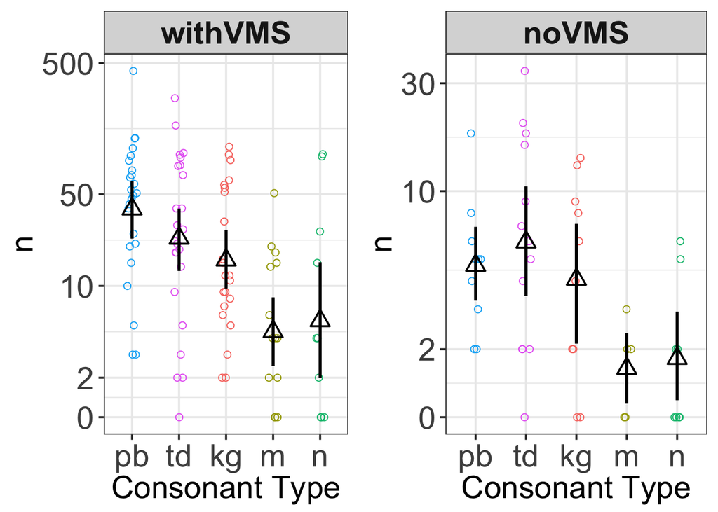

```r
Figure1a <- ggplot(subset(vmscount, VMSgroup == "withVMS"), aes(x=Consonant, y=log10(n))) +
  stat_summary(fun.y=mean, geom = "point", aes(group = subj, colour = Consonant), shape=1, size=2,
               position = position_jitter(width = .1, height=0)) +
  stat_summary(fun.data=mean_cl_boot, geom = "pointrange", shape=2, size=1) +
  scale_x_discrete(limits = c("p", "t", "k", "m", "n"),
                   labels = c("pb", "td", "kg", "m", "n")) +
  theme_bw(base_size=15) +
  scale_y_continuous(breaks=c(0, .301, 1, 1.699, 2.69897), labels=c(0, 2, 10, 50, 500)) +
  xlab("Consonant Type") +
  ylab("n") +
  theme(legend.position = "none",
        axis.title = element_text(size=22),
           axis.text = element_text(size=22),
        strip.text = element_text(face="bold", size=22,lineheight=7.0)) +
  facet_wrap(~VMSgroup)
Figure1b <- ggplot(subset(vmscount, VMSgroup == "noVMS"), aes(x=Consonant, y=log10(n))) +
  stat_summary(fun.y=mean, geom = "point", aes(group = subj, colour = Consonant), shape=1, size=2,
               position = position_jitter(width = .1, height=0)) +
  stat_summary(fun.data=mean_cl_boot, geom = "pointrange", shape=2, size=1) +
  scale_x_discrete(limits = c("p", "t", "k", "m", "n"),
                   labels = c("pb", "td", "kg", "m", "n")) +
  theme_bw(base_size=15) +
  scale_y_continuous(breaks=c(0, .301, 1, 1.477, 1.699, 2), labels=c(0, 2, 10, 30, 50, 100)) +
  xlab("Consonant Type") +
  ylab("n") +
  theme(legend.position = "none",
        axis.title = element_text(size=22),
           axis.text = element_text(size=22),
        strip.text = element_text(face="bold", size=22,lineheight=7.0)) +
  facet_wrap(~VMSgroup)

multiplot(Figure1a, Figure1b, cols=2)
```

# Infant Production: Video recordings

On average, infants produced 44 CP tokens in the hour-long video recordings and 4.34 CP types. Once again, withVMS infants produced significantly more tokens than noVMS infants, while the number of CP types was marginally higher for withVMS infants.

```r
wilcox.test(subset(ProdData, VMSgroup == "withVMS")$CPtokens, subset(ProdData, VMSgroup == "noVMS")$CPtokens, conf.int=T) # p<.001
```

```
##
##  Wilcoxon rank sum test with continuity correction
##
## data:  subset(ProdData, VMSgroup == "withVMS")$CPtokens and subset(ProdData, VMSgroup == "noVMS")$CPtokens
## W = 402.5, p-value = 0.0001337
## alternative hypothesis: true location shift is not equal to 0
## 95 percent confidence interval:
##  15.00005 57.99998
## sample estimates:
## difference in location
##               33.00009
```

```r
cliff.delta(d = subset(ProdData, VMSgroup == "withVMS")$CPtokens,
     f = subset(ProdData, VMSgroup == "noVMS")$CPtokens)   # .68 large
```

```
##
## Cliff's Delta
##
## delta estimate: 0.6770833 (large)
## 95 percent confidence interval:
##     lower     upper
## 0.3782482 0.8481163
```

```r
ProdData %>% group_by(VMSgroup) %>% summarise(meantok = mean(CPtokens))
```

```
## # A tibble: 2 x 2
##   VMSgroup meantok
##   <chr>      <dbl>
## 1 noVMS       23.6
## 2 withVMS     60.1
```

```r
wilcox.test(subset(ProdData, VMSgroup == "withVMS")$CPtypes, subset(ProdData, VMSgroup == "noVMS")$CPtypes, conf.int=T) # p=.06
```

```
##
##  Wilcoxon rank sum test with continuity correction
##
## data:  subset(ProdData, VMSgroup == "withVMS")$CPtypes and subset(ProdData, VMSgroup == "noVMS")$CPtypes
## W = 317.5, p-value = 0.06037
## alternative hypothesis: true location shift is not equal to 0
## 95 percent confidence interval:
##  -5.091794e-05  1.000016e+00
## sample estimates:
## difference in location
##              0.9999707
```

```r
cliff.delta(d = subset(ProdData, VMSgroup == "withVMS")$CPtypes,
     f = subset(ProdData, VMSgroup == "noVMS")$CPtypes)   # .32 small
```

```
##
## Cliff's Delta
##
## delta estimate: 0.3229167 (small)
## 95 percent confidence interval:
##       lower       upper
## -0.02124075  0.59865211
```

```r
ProdData %>% group_by(VMSgroup) %>% summarise(meantyp = mean(CPtypes))
```

```
## # A tibble: 2 x 2
##   VMSgroup meantyp
##   <chr>      <dbl>
## 1 noVMS       3.95
## 2 withVMS     4.67
```

As expected, withVMS infants produced their INREP consonants significantly more often (mean tokens=23.3, SD=21.7) than their OUTREP consonants (mean tokens=8.7, SD= 7.5; Est.Diff.=-9.6, p<.01).

```r
compareRecordings %>% filter(VMS.Prod.Cong == T) %>% summarise(meanOverall = mean(meanProd),
                                                               sdOverall = sd(meanProd))
```

```
## # A tibble: 1 x 2
##   meanOverall sdOverall
##         <dbl>     <dbl>
## 1        23.3      21.7
```

```r
compareRecordings %>% filter(VMS.Prod.Cong == F) %>% summarise(meanOverall = mean(meanProd),
                                                               sdOverall = sd(meanProd))
```

```
## # A tibble: 1 x 2
##   meanOverall sdOverall
##         <dbl>     <dbl>
## 1        8.66      7.48
```

```r
shapiro.test(compareRecordings$meanProd) # not normal
```

```
##
##  Shapiro-Wilk normality test
##
## data:  compareRecordings$meanProd
## W = 0.73129, p-value = 4.953e-08
```

```r
wilcox.test(compareRecordings.spread$VMS.Prod.Cong, compareRecordings.spread$VMS.Prod.Incong, paired=T, conf.int=T)
```

```
##
##  Wilcoxon signed rank test with continuity correction
##
## data:  compareRecordings.spread$VMS.Prod.Cong and compareRecordings.spread$VMS.Prod.Incong
## V = 258.5, p-value = 0.00203
## alternative hypothesis: true location shift is not equal to 0
## 95 percent confidence interval:
##   4.083367 24.124996
## sample estimates:
## (pseudo)median
##       9.625573
```

```r
wilcoxonPairedR(x = compareRecordings$meanProd,
                g = compareRecordings$VMS.Prod.Cong) # r= .63
```

```
##     r
## 0.633
```

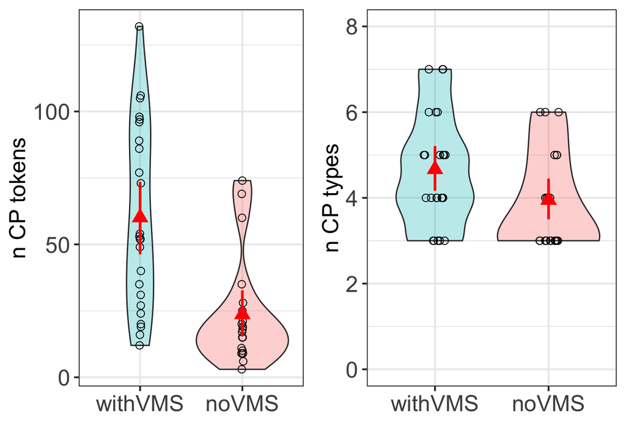

```r
Figure2a <- ggplot(ProdData, aes(x=VMSgroup, y=CPtokens)) +
  geom_violin(aes(fill = VMSgroup), alpha=.3) +
  stat_summary(fun.y=mean, geom = "point", aes(group = subj), shape=1, size=2.5, position=position_jitter(height = 0, width = 0.01)) +
  stat_summary(fun.data=mean_cl_boot, geom = "pointrange", colour='red', shape=17, size=1) +
  scale_x_discrete(limits = c("withVMS", "noVMS"), labels = c("withVMS", "noVMS")) +
    theme_bw(base_size=15) +
     theme(axis.text = element_text(size=18),
           axis.title = element_text(size=18),
           legend.position="none") +
  ylab("n CP tokens") +
  xlab('')
  Figure2b <- ggplot(ProdData, aes(x=VMSgroup, y=CPtypes)) +
    geom_violin(aes(fill = VMSgroup), alpha=.3) +
  stat_summary(fun.y=mean, geom = "point", aes(group = subj), shape=1, size=2.5, position=position_jitter(height = 0, width = .1)) +
  stat_summary(fun.data=mean_cl_boot, geom = "pointrange", colour='red', shape=17, size=1) +
  scale_x_discrete(limits = c("withVMS", "noVMS"), labels = c("withVMS", "noVMS")) +
  coord_cartesian(ylim=c(0, 8)) +
  scale_y_continuous(breaks=seq(0, 8, 2))  +
   ylab("n CP types") +
  xlab('') +
  theme_bw(base_size=15) +
  theme(legend.position="none",
        axis.title = element_text(size=18),
        axis.text = element_text(size=18))


multiplot(Figure2a, Figure2b, cols=2)
```

## Input prompts

Overall, 1451 CPs in the data were produced alongside either an input prompt or an attended object; 527 CPs were produced alongside both an input prompt and an attended object.

```r
CPdata %>% filter(C1Prompt != "none") %>% tally() # 936
```

```
## # A tibble: 1 x 1
##       n
##   <int>
## 1   936
```

```r
CPdata %>% mutate(nostim = ifelse(C1Obj == "none" & C1Prompt == "none", T, F)) %>%
  filter(nostim == FALSE) %>% tally() # 1451
```

```
## # A tibble: 1 x 1
##       n
##   <int>
## 1  1451
```

```r
CPdata %>% mutate(bothstim = ifelse(C1Obj != "none" & C1Prompt != "none", T, F)) %>%
  filter(bothstim == TRUE) %>% tally() # 527
```

```
## # A tibble: 1 x 1
##       n
##   <int>
## 1   527
```

```r
ProdData %>% summarize(meanPrompt = mean(nPrompt/CPtokens, na.rm=T), #.51
                   sdPrompt = sd(nPrompt/CPtokens, na.rm=T), #.18
                   Promptmatch = mean(Prod.Prompt.match.PC, na.rm=T), #.5
                   SDPromptmatch = sd(Prod.Prompt.match.PC, na.rm=T)) #.23
```

```
## # A tibble: 1 x 4
##   meanPrompt sdPrompt Promptmatch SDPromptmatch
##        <dbl>    <dbl>       <dbl>         <dbl>
## 1      0.515    0.183       0.485         0.232
```

```r
#shapiro.test(ProdData$Prod.Prompt.match.PC) # p=.048

#t.test(Prod.Prompt.match.PC ~ VMSgroup, ProdData) # p=.057

wilcox.test(subset(ProdData, VMSgroup=="withVMS")$Prod.Prompt.match.PC,
            subset(ProdData, VMSgroup=="noVMS")$Prod.Prompt.match.PC, conf.int=T) # p=.11, EstDiff=-.11
```

```
##
##  Wilcoxon rank sum test with continuity correction
##
## data:  subset(ProdData, VMSgroup == "withVMS")$Prod.Prompt.match.PC and subset(ProdData, VMSgroup == "noVMS")$Prod.Prompt.match.PC
## W = 308, p-value = 0.1114
## alternative hypothesis: true location shift is not equal to 0
## 95 percent confidence interval:
##  -0.02769612  0.30005964
## sample estimates:
## difference in location
##              0.1144253
```

```r
cliff.delta(d = subset(ProdData, VMSgroup=="withVMS")$Prod.Prompt.match.PC,
     f = subset(ProdData, VMSgroup=="noVMS")$Prod.Prompt.match.PC)   # .28 small
```

```
##
## Cliff's Delta
##
## delta estimate: 0.2833333 (small)
## 95 percent confidence interval:
##       lower       upper
## -0.09283072  0.58871949
```

```r
ProdData %>% group_by(VMSgroup) %>% summarise(meanInput = mean(Prod.Prompt.match.PC),
                                              sdInput = sd(Prod.Prompt.match.PC))
```

```
## # A tibble: 2 x 3
##   VMSgroup meanInput sdInput
##   <chr>        <dbl>   <dbl>
## 1 noVMS        0.408   0.278
## 2 withVMS      0.548   0.167
```

```r
prompt.real <- ProdData %>%
  select(subj, month, VMSgroup, Prod.Prompt.match.PC) %>%
  ungroup() %>%
  rename(PC = Prod.Prompt.match.PC) %>%
  mutate(Type = 'Real')

prompt.scramble <- data.scrambled %>%
  ungroup() %>%
  select(subj, month, VMSgroup, Prod.Prompt.match.PC) %>%
  rename(PC = Prod.Prompt.match.PC) %>%
  mutate(Type = 'Scrambled')

scramble.comparison.prompt <- rbind(prompt.real, prompt.scramble)

#shapiro.test(scramble.comparison.prompt$PC) # not normal

scramble.comparison.prompt %>% group_by(Type, VMSgroup) %>% summarise(meanscramble = mean(PC),
                                                                      sdscramble = sd(PC))
```

```
## # A tibble: 4 x 4
## # Groups:   Type [2]
##   Type      VMSgroup meanscramble sdscramble
##   <chr>     <chr>           <dbl>      <dbl>
## 1 Real      noVMS           0.408      0.278
## 2 Real      withVMS         0.548      0.167
## 3 Scrambled noVMS           0.202      0.155
## 4 Scrambled withVMS         0.216      0.135
```

```r
wilcox.test(subset(prompt.real, VMSgroup == "withVMS")$PC,
            subset(prompt.scramble, VMSgroup == "withVMS")$PC, conf.int = T) # Significant, p<.001
```

```
##
##  Wilcoxon rank sum test with continuity correction
##
## data:  subset(prompt.real, VMSgroup == "withVMS")$PC and subset(prompt.scramble, VMSgroup == "withVMS")$PC
## W = 548.5, p-value = 8.251e-08
## alternative hypothesis: true location shift is not equal to 0
## 95 percent confidence interval:
##  0.2349130 0.4255568
## sample estimates:
## difference in location
##              0.3259157
```

```r
cliff.delta(d = subset(prompt.real, VMSgroup == "withVMS")$PC,
     f = subset(prompt.scramble, VMSgroup == "withVMS")$PC)   # .90 large
```

```
##
## Cliff's Delta
##
## delta estimate: 0.9045139 (large)
## 95 percent confidence interval:
##     lower     upper
## 0.6968941 0.9722455
```

```r
wilcox.test(subset(prompt.real, VMSgroup == "noVMS")$PC,
            subset(prompt.scramble, VMSgroup == "noVMS")$PC, conf.int = T) # Significant, p<.05
```

```
##
##  Wilcoxon rank sum test with continuity correction
##
## data:  subset(prompt.real, VMSgroup == "noVMS")$PC and subset(prompt.scramble, VMSgroup == "noVMS")$PC
## W = 290.5, p-value = 0.01432
## alternative hypothesis: true location shift is not equal to 0
## 95 percent confidence interval:
##  0.0357705 0.3725936
## sample estimates:
## difference in location
##              0.2372605
```

```r
cliff.delta(d = subset(prompt.real, VMSgroup == "noVMS")$PC,
     f = subset(prompt.scramble, VMSgroup == "noVMS")$PC)   # .45 medium
```

```
##
## Cliff's Delta
##
## delta estimate: 0.4525 (medium)
## 95 percent confidence interval:
##      lower      upper
## 0.06947429 0.71925155
```

```r
Figure3a <-
  ggplot(scramble.comparison.prompt, aes(x=Type, y=PC, shape = Type, color = VMSgroup))+
  geom_point(aes(group=VMSgroup), size = 5, position=position_dodge(-.2)) +
  stat_summary(fun.data=mean_cl_boot, geom = "pointrange", aes(shape=Type, fill = VMSgroup),
               size=1.5, position = position_dodge(-.2), colour = "grey32", show.legend = FALSE) +
  stat_summary(fun.y = mean, aes(group=VMSgroup, colour=VMSgroup), geom='line', size=.8, position = position_dodge(-.2), show.legend = FALSE) +
    scale_shape_manual(name = "VMSgroup",
                      labels = c("noVMS", "withVMS"),
                       values=c(21,24)) +
    scale_colour_manual(name = "VMSgroup",
                     labels = c("noVMS", "withVMS"),
                      values = c("#F8766D","#00BFC4")) +
  xlab("Data type") +
  ylab('% Congruent CPs') +
  ggtitle("Caregiver Prompt") +
  theme_bw(base_size=15) +
   theme(axis.text = element_text(size = 20),
         axis.title = element_text(size=20),
         legend.title = element_blank(),
         legend.justification=c(1,1), legend.position=c(1,.99)) +
  guides(shape = FALSE,
         color = guide_legend(override.aes = list(shape=15)))

#plot(Figure3a)
```

A paired Wilcoxon Signed-Rank test showed that withVMS infants produced significantly more CPs to match caregiver prompts when the prompt was INREP (M=.71, SD=.24) than when it was OUTREP (M=.38, SD=.23; Est.Diff.=.35, p=.001).

```r
#since value of PC for noVMS is all NA, no need to even subset
shapiro.test(subset(match.data.Prompt, VMSgroup=="withVMS")$PC) #normal
```

```
##
##  Shapiro-Wilk normality test
##
## data:  subset(match.data.Prompt, VMSgroup == "withVMS")$PC
## W = 0.95884, p-value = 0.09059
```

```r
# t.test(subset(match.data.Prompt.spread, VMSgroup=="withVMS")$inREP,
# subset(match.data.Prompt.spread, VMSgroup=="withVMS")$outREP, conf.int=T, paired = T) # p<.001

wilcox.test(subset(match.data.Prompt.spread, VMSgroup=="withVMS")$inREP,
subset(match.data.Prompt.spread, VMSgroup=="withVMS")$outREP, conf.int=T, paired = T) # p=.001, Est.Diff=.34
```

```
##
##  Wilcoxon signed rank test with continuity correction
##
## data:  subset(match.data.Prompt.spread, VMSgroup == "withVMS")$inREP and subset(match.data.Prompt.spread, VMSgroup == "withVMS")$outREP
## V = 264.5, p-value = 0.001125
## alternative hypothesis: true location shift is not equal to 0
## 95 percent confidence interval:
##  0.1486303 0.5013678
## sample estimates:
## (pseudo)median
##      0.3477573
```

```r
wilcoxonPairedR(x = subset(match.data.Prompt, VMSgroup == "withVMS")$PC,
                g = subset(match.data.Prompt, VMSgroup == "withVMS")$Type) # r= .67
```

```
##     r
## 0.668
```

```r
match.data.Prompt %>%
  filter(VMSgroup == "withVMS") %>%
  group_by(Type) %>%
  summarise(meanmatch = mean(PC, na.rm = T),
            sdmatch = sd(PC, na.rm = T))
```

```
## # A tibble: 2 x 3
##   Type   meanmatch sdmatch
##   <chr>      <dbl>   <dbl>
## 1 inREP      0.707   0.242
## 2 outREP     0.383   0.228
```

```r
Figure4a <-
  ggplot(match.data.Prompt, aes(x=Type, y=PC, shape = Type, color = VMSgroup))+
  geom_point(aes(group=VMSgroup), size = 5, position=position_dodge(-.2)) +
  geom_line(aes(group=subj), colour='grey63', position = position_nudge(x = -.05), linetype=6) +
  stat_summary(fun.data=mean_cl_boot, geom = "pointrange", aes(shape=Type, fill = VMSgroup),
               size=1.5, position = position_dodge(-.2), colour = "grey32", show.legend = FALSE) +
  stat_summary(fun.y = mean, aes(group=VMSgroup, colour=VMSgroup), geom='line', size=.8, position = position_dodge(-.2), show.legend = FALSE) +
    scale_shape_manual(values=c(23,25)) +
  xlab("Consonant Type") +
  ylab('% Congruent CPs') +
  ggtitle("Caregiver Prompt") +
  theme_bw(base_size=15) +
   theme(axis.text = element_text(size = 20),
         axis.title = element_text(size=20),
         legend.title = element_blank(),
         legend.justification=c(1,1), legend.position=c(1,.99)) +
  guides(shape = FALSE,
         color = guide_legend(override.aes = list(shape=15)))

#plot(Figure4a)
```

A Wilcoxon Rank Sum test revealed no difference between withVMS (M=.38, SD=.23) and noVMS infants’ CPs (M=.41, SD=.28) when the CP was not INREP (Est.Diff.=.02, p=.74).

```r
match.data.Prompt %>%
  filter(Type == "outREP") %>%
  summarise(meanMatch = mean(PC, na.rm=T),
              sdMatch = sd(PC, na.rm=T))
```

```
## # A tibble: 1 x 2
##   meanMatch sdMatch
##       <dbl>   <dbl>
## 1     0.395   0.249
```

```r
match.data.Prompt %>%
  filter(Type == "outREP") %>%
  group_by(VMSgroup) %>%
  summarise(meanMatch = mean(PC, na.rm=T),
            sdMatch = sd(PC, na.rm=T))
```

```
## # A tibble: 2 x 3
##   VMSgroup meanMatch sdMatch
##   <chr>        <dbl>   <dbl>
## 1 noVMS        0.408   0.278
## 2 withVMS      0.383   0.228
```

```r
shapiro.test(subset(match.data.Prompt, Type=='outREP')$PC)#normal
```

```
##
##  Shapiro-Wilk normality test
##
## data:  subset(match.data.Prompt, Type == "outREP")$PC
## W = 0.94944, p-value = 0.05245
```

```r
#t.test(PC ~ VMSgroup, subset(match.data.Prompt, Type=='outREP'), conf.int=T) # ns

wilcox.test(subset(match.data.Prompt, VMSgroup == "withVMS" & Type == "outREP")$PC,
            subset(match.data.Prompt, VMSgroup == "noVMS" & Type == "outREP")$PC, conf.int = T) # ns
```

```
##
##  Wilcoxon rank sum test with continuity correction
##
## data:  subset(match.data.Prompt, VMSgroup == "withVMS" & Type == "outREP")$PC and subset(match.data.Prompt, VMSgroup == "noVMS" & Type == "outREP")$PC
## W = 225.5, p-value = 0.741
## alternative hypothesis: true location shift is not equal to 0
## 95 percent confidence interval:
##  -0.1978669  0.1428845
## sample estimates:
## difference in location
##            -0.02375371
```

```r
cliff.delta(d = subset(match.data.Prompt, VMSgroup == "withVMS" & Type == "outREP")$PC,
     f = subset(match.data.Prompt, VMSgroup == "noVMS" & Type == "outREP")$PC)   # -.06 negligible
```

```
##
## Cliff's Delta
##
## delta estimate: -0.06041667 (negligible)
## 95 percent confidence interval:
##      lower      upper
## -0.4004317  0.2942222
```

## Attended objects

On average, 56% of CPs (SD=.22) were produced while attending to an object, and 38% showed a phonological match with the attended object (SD=.27). To test whether the proportion of CPs that matched attended objects differed by VMS group, we ran a Wilcoxon Rank Sum test with proportion of matching CPs as our dependent variable and VMS group as a factor. This showed that VMS group accounted for a significant amount of variance in the data (Est.Diff.=-.28, p<.01; Table 4).

```r
CPdata %>% filter(C1Obj != "none") %>% tally() # 1042
```

```
## # A tibble: 1 x 1
##       n
##   <int>
## 1  1042
```

```r
ProdData %>% summarize(meanObject = mean(nObj/CPtokens, na.rm=T), #.56
                   sdObject = sd(nObj/CPtokens, na.rm=T), #.22
                   Objectmatch = mean(Prod.Obj.match.PC, na.rm=T), # .39
                   SDobjectmatch = sd(Prod.Obj.match.PC, na.rm=T)) # 28
```

```
## # A tibble: 1 x 4
##   meanObject sdObject Objectmatch SDobjectmatch
##        <dbl>    <dbl>       <dbl>         <dbl>
## 1      0.555    0.218       0.382         0.274
```

```r
wilcox.test(subset(ProdData, VMSgroup == "withVMS")$Prod.Obj.match.PC,
            subset(ProdData, VMSgroup == "noVMS")$Prod.Obj.match.PC, conf.int = T) # p<.01
```

```
##
##  Wilcoxon rank sum test with continuity correction
##
## data:  subset(ProdData, VMSgroup == "withVMS")$Prod.Obj.match.PC and subset(ProdData, VMSgroup == "noVMS")$Prod.Obj.match.PC
## W = 348, p-value = 0.003325
## alternative hypothesis: true location shift is not equal to 0
## 95 percent confidence interval:
##  0.08956501 0.43242759
## sample estimates:
## difference in location
##              0.2770976
```

```r
cliff.delta(d = subset(ProdData, VMSgroup == "withVMS")$Prod.Obj.match.PC,
     f = subset(ProdData, VMSgroup == "noVMS")$Prod.Obj.match.PC)   # .46 medium
```

```
##
## Cliff's Delta
##
## delta estimate: 0.4625 (medium)
## 95 percent confidence interval:
##     lower     upper
## 0.1443162 0.6940060
```

```r
obj.real <- ProdData %>%
  select(subj, month, VMSgroup, Prod.Obj.match.PC) %>%
  ungroup() %>%
  rename(PC = Prod.Obj.match.PC) %>%
  mutate(Type = 'Real')

obj.scramble <- data.scrambled %>%
  ungroup() %>%
  select(subj, month, VMSgroup, Prod.Obj.match.PC) %>%
  rename(PC = Prod.Obj.match.PC) %>%
  mutate(Type = 'Scrambled')

scramble.comparison.object <- rbind(obj.real, obj.scramble)

scramble.comparison.object %>% group_by(Type, VMSgroup) %>% summarise(meanscramble = mean(PC, na.rm=T),
                                                                      sdscramble = sd(PC, na.rm=T))
```

```
## # A tibble: 4 x 4
## # Groups:   Type [2]
##   Type      VMSgroup meanscramble sdscramble
##   <chr>     <chr>           <dbl>      <dbl>
## 1 Real      noVMS           0.246      0.222
## 2 Real      withVMS         0.490      0.266
## 3 Scrambled noVMS           0.245      0.159
## 4 Scrambled withVMS         0.242      0.114
```

```r
#shapiro.test(scramble.comparison.object$PC) # not normal

wilcox.test(subset(obj.real, VMSgroup == "withVMS")$PC,
            subset(obj.scramble, VMSgroup == "withVMS")$PC, conf.int = T) # p<.001
```

```
##
##  Wilcoxon rank sum test with continuity correction
##
## data:  subset(obj.real, VMSgroup == "withVMS")$PC and subset(obj.scramble, VMSgroup == "withVMS")$PC
## W = 463.5, p-value = 0.0003055
## alternative hypothesis: true location shift is not equal to 0
## 95 percent confidence interval:
##  0.1486807 0.3957865
## sample estimates:
## difference in location
##              0.2801027
```

```r
cliff.delta(d = subset(obj.real, VMSgroup == "withVMS")$PC,
     f = subset(obj.scramble, VMSgroup == "withVMS")$PC)   # .61 large
```

```
##
## Cliff's Delta
##
## delta estimate: 0.609375 (large)
## 95 percent confidence interval:
##     lower     upper
## 0.2482584 0.8217871
```

```r
wilcox.test(subset(obj.real, VMSgroup == "noVMS")$PC,
            subset(obj.scramble, VMSgroup == "noVMS")$PC, conf.int = T) # ns
```

```
##
##  Wilcoxon rank sum test with continuity correction
##
## data:  subset(obj.real, VMSgroup == "noVMS")$PC and subset(obj.scramble, VMSgroup == "noVMS")$PC
## W = 190.5, p-value = 1
## alternative hypothesis: true location shift is not equal to 0
## 95 percent confidence interval:
##  -0.166641  0.119029
## sample estimates:
## difference in location
##           4.238364e-05
```

```r
cliff.delta(d = subset(obj.real, VMSgroup == "noVMS")$PC,
     f = subset(obj.scramble, VMSgroup == "noVMS")$PC)   # <.01 negligible
```

```
##
## Cliff's Delta
##
## delta estimate: 0.002631579 (negligible)
## 95 percent confidence interval:
##      lower      upper
## -0.3489358  0.3535496
```

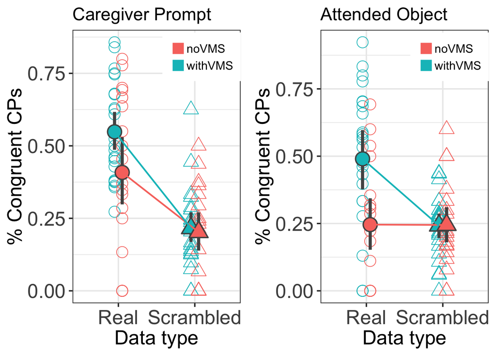

```r
Figure3b <-
  ggplot(scramble.comparison.object, aes(x=Type, y=PC, shape = Type, color = VMSgroup))+
  geom_point(aes(group=VMSgroup), size = 5, position=position_dodge(-.2)) +
  stat_summary(fun.data=mean_cl_boot, geom = "pointrange", aes(shape=Type, fill = VMSgroup),
               size=1.5, position = position_dodge(-.2), colour = "grey32", show.legend = FALSE) +
  stat_summary(fun.y = mean, aes(group=VMSgroup, colour=VMSgroup), geom='line', size=.8, position = position_dodge(-.2), , show.legend = FALSE) +
scale_shape_manual(name = "VMSgroup",
                      labels = c("noVMS", "withVMS"),
                       values=c(21,24)) +
    scale_colour_manual(name = "VMSgroup",
                     labels = c("noVMS", "withVMS"),
                      values = c("#F8766D","#00BFC4")) +
    xlab("Data type") +
  ylab('% Congruent CPs') +
  ggtitle("Attended Object") +
  theme_bw(base_size=15) +
   theme(axis.text = element_text(size = 20),
         axis.title = element_text(size=20),
         legend.title = element_blank(),
         legend.justification=c(1,1), legend.position=c(1,.99)) +
  guides(shape = FALSE,
         color = guide_legend(override.aes = list(shape=15)))

#plot(Figure3b)
multiplot(Figure3a, Figure3b, cols=2)
```

Similar to the caregiver prompts, infants produced more object-matching CPs when the object’s label provided a phonological match with their VMS inventory; this difference was marginally significant (Est.Diff.=.32, p=.056).

```r
#shapiro.test(subset(match.data.Prompt, VMSgroup=="withVMS")$PC) # normal

match.data.Object %>%
  filter(VMSgroup == "withVMS") %>%
  group_by(Type) %>%
  summarise(meanmatch = mean(PC, na.rm = T),
            sdmatch = sd(PC, na.rm = T))
```

```
## # A tibble: 2 x 3
##   Type   meanmatch sdmatch
##   <chr>      <dbl>   <dbl>
## 1 inREP      0.570   0.373
## 2 outREP     0.358   0.323
```

```r
#
# t.test(subset(match.data.Object.spread, VMSgroup=="withVMS")$inREP,
# subset(match.data.Object.spread, VMSgroup=="withVMS")$outREP, conf.int=T, paired = T) # p=.052

wilcox.test(subset(match.data.Object.spread, VMSgroup=="withVMS")$inREP,
subset(match.data.Object.spread, VMSgroup=="withVMS")$outREP, conf.int=T, paired = T) # p=.056, Est Diff = .32
```

```
##
##  Wilcoxon signed rank test with continuity correction
##
## data:  subset(match.data.Object.spread, VMSgroup == "withVMS")$inREP and subset(match.data.Object.spread, VMSgroup == "withVMS")$outREP
## V = 171, p-value = 0.05592
## alternative hypothesis: true location shift is not equal to 0
## 95 percent confidence interval:
##  -0.01382522  0.51817996
## sample estimates:
## (pseudo)median
##      0.3220709
```

```r
wilcoxonPairedR(x = subset(match.data.Object, VMSgroup == "withVMS")$PC,
                g = subset(match.data.Object, VMSgroup == "withVMS")$Type) # r= .42
```

```
##     r
## 0.421
```

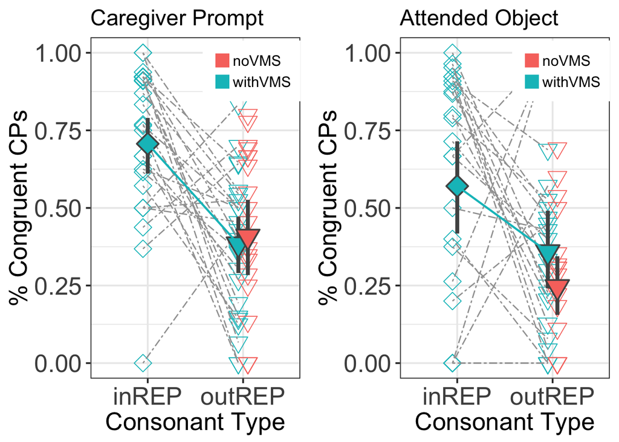

```r
Figure4b <- ggplot(match.data.Object, aes(x=Type, y=PC)) +
  geom_point(aes(colour=VMSgroup, shape=Type), size=5, position = position_dodge(-.2)) +
  geom_line(aes(group=subj), colour='grey63',position = position_nudge(x = -.05), linetype=6) +
  stat_summary(fun.data=mean_cl_boot, geom = "pointrange", aes(shape=Type, fill= VMSgroup), colour = "gray32", size=1.5, position = position_dodge(-.2), show.legend = FALSE) +
  stat_summary(fun.y = mean, aes(group=VMSgroup, colour=VMSgroup), geom='line', size=.8, position = position_dodge(-.2), show.legend = FALSE) +
  scale_shape_manual(values=c(23,25)) +
  ylab("% Congruent CPs") +
  xlab("Consonant Type") +
  ggtitle("Attended Object") +
  theme_bw(base_size=15) +
   theme(axis.text.x = element_text(size = 20),
         axis.title.x = element_text(size=20),
         axis.title.y = element_text(size=20),
         axis.text.y = element_text(size=20),
                  legend.title = element_blank(),
         legend.justification=c(1,1), legend.position=c(1,.99)) +
  guides(shape = FALSE,
         color = guide_legend(override.aes = list(shape=15)))

multiplot(Figure4a, Figure4b, cols=2)
```

```r
#plot(Figure4)
```

Overall, 31% of OUTREP CPs matched an attended object (SD=.29), and this did not differ between VMS groups (Est.Diff.=-.08, p=.32; withVMS: M=.36, SD=.32; noVMS: M=.25, SD=.22).

```r
match.data.Object %>% filter(Type == "outREP") %>% summarise(meanMatch = mean(PC, na.rm=T),
                                sdMatch = sd(PC, na.rm=T))
```

```
## # A tibble: 1 x 2
##   meanMatch sdMatch
##       <dbl>   <dbl>
## 1     0.309   0.285
```

```r
#t.test(PC ~ VMSgroup, subset(match.data.Object, Type=='outREP'), conf.int=T) # ns

wilcox.test(subset(match.data.Object, VMSgroup == "withVMS" & Type == "outREP")$PC,
            subset(match.data.Object, VMSgroup == "noVMS" & Type == "outREP")$PC, conf.int = T) # ns
```

```
##
##  Wilcoxon rank sum test with continuity correction
##
## data:  subset(match.data.Object, VMSgroup == "withVMS" & Type == "outREP")$PC and subset(match.data.Object, VMSgroup == "noVMS" & Type == "outREP")$PC
## W = 269, p-value = 0.3178
## alternative hypothesis: true location shift is not equal to 0
## 95 percent confidence interval:
##  -0.07139138  0.25004494
## sample estimates:
## difference in location
##             0.07892115
```

```r
cliff.delta(d = subset(match.data.Object, VMSgroup == "withVMS" & Type == "outREP")$PC,
            f = subset(match.data.Object, VMSgroup == "noVMS" & Type == "outREP")$PC) # .13 negligible
```

```
##
## Cliff's Delta
##
## delta estimate: 0.1270833 (negligible)
## 95 percent confidence interval:
##      lower      upper
## -0.2038803  0.4319782
```

```r
match.data.Object %>% filter(Type == "outREP") %>% group_by(VMSgroup) %>%
  summarise(meanMatch = mean(PC, na.rm=T),
            sdMatch = sd(PC, na.rm=T))
```

```
## # A tibble: 2 x 3
##   VMSgroup meanMatch sdMatch
##   <chr>        <dbl>   <dbl>
## 1 noVMS        0.246   0.222
## 2 withVMS      0.358   0.323
```

# Discussion

```r
CPdata %>% filter(cgresponse == "None" | is.na(cgresponse)) %>% tally() #1404
```

```
## # A tibble: 1 x 1
##       n
##   <int>
## 1  1404
```

```r
1404/1916 #73%
```

```
## [1] 0.7327766
```